# Initial Models

# Corplots

```r
seph <- read.csv("sephora_data_clean.csv", header = TRUE)
```

## Overall Corrplot

First I’d like to make a corrplot. Columns 22:71 contain the binary ingredient classifications

```r
ingredients <- colnames(seph)[22:71]
seph_in <- seph[, which(names(seph) %in% ingredients)]
# Column 36 is WAAAY too long. Let's fix thst
colnames(seph_in)[36] <- "Talc"
head(seph_in,10)
```

```
##    Phenoxyethanol Glycerin Caprylyl.Glycol Dimethicone Silica Butylene.Glycol
## 1               0        0               0           0      0               0
## 2               0        0               0           0      0               0
## 3               0        0               0           0      0               0
## 4               0        0               0           0      0               0
## 5               0        0               0           0      0               0
## 6               0        0               0           0      0               0
## 7               0        0               0           0      0               0
## 8               0        0               0           0      0               0
## 9               0        0               0           0      0               0
## 10              0        0               0           0      0               0
##    Limonene Tocopherol Water Ethylhexylglycerin Linalool Fragrance Citric.Acid
## 1         1          0     1                  0        1         1           0
## 2         0          0     0                  0        0         0           0
## 3         1          0     1                  0        1         1           0
```

[output cut: 117 more lines]

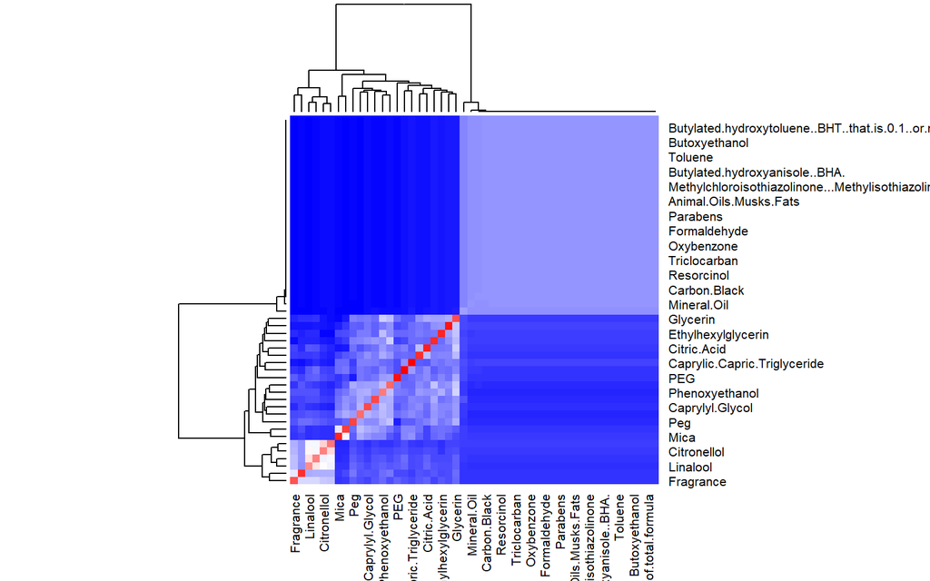

```r
phi <- cor(seph_in, method = "pearson")
# corrplot.mixed(phi, order = 'AOE')
heatmap(phi, col = colorRampPalette(c("blue", "white", "red"))(100))
```

Very uninformative, so let’s try again for the top 10 ingredients. I’m making a function to do so. To investigate a range like top 25-35, we’ll need to modify the dataframe being fed in

## Corplots broken up

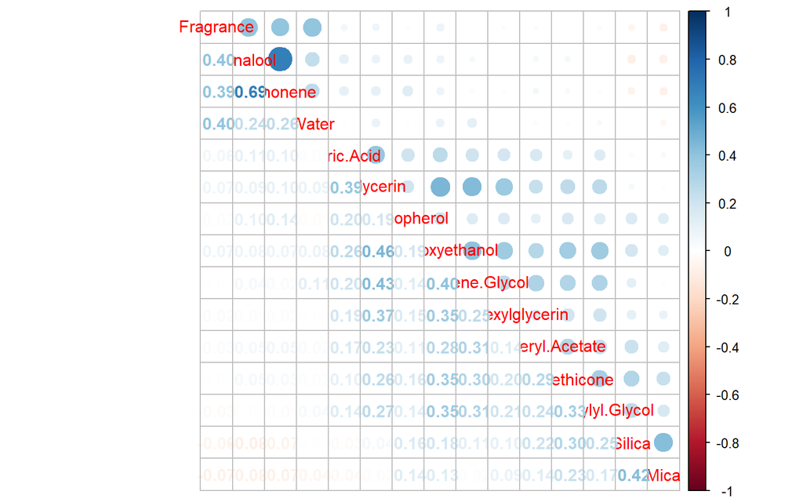

```r
# This function creates a corrplot based off inredients in our dataframe,
corrplot_range <- function(df, top=10, order = "AOE"){
  names <- colnames(df)[1:top]
  df_top <- df[, which(names(df) %in% names)]
  phi <- cor(df_top, method = "pearson")
  corrplot.mixed(phi, order = order)

  return()
}

corrplot_range(seph_in, 15)
```

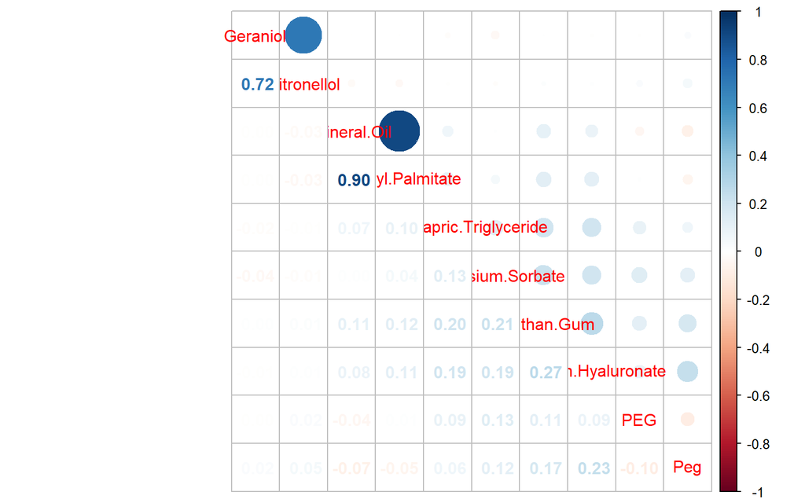

```r
corrplot_range(seph_in[, 16:25], 10)
```

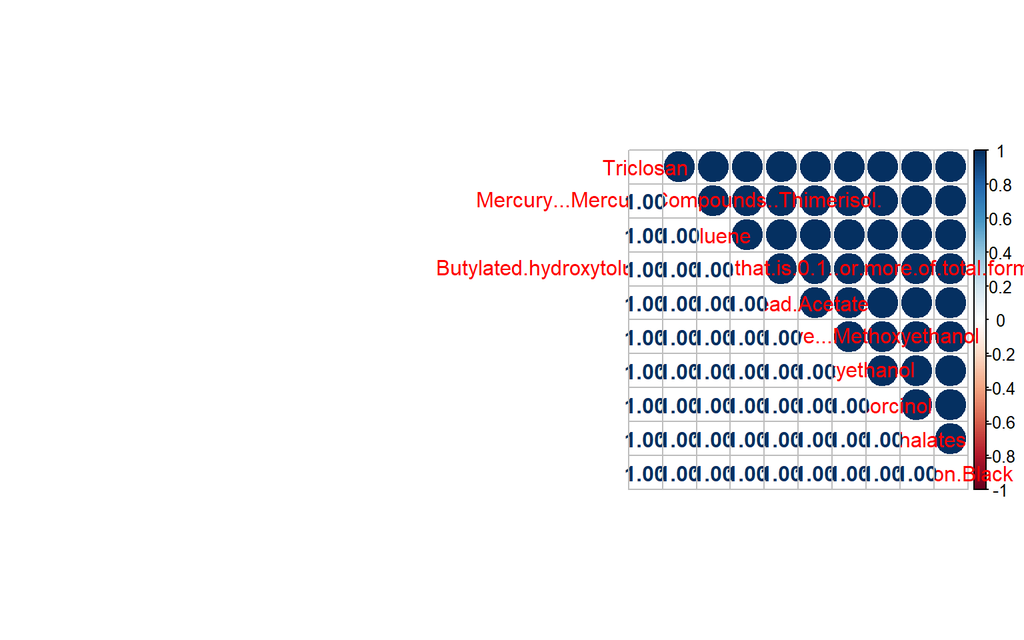

```r
corrplot_range(seph_in[, 26:35], 10)
```

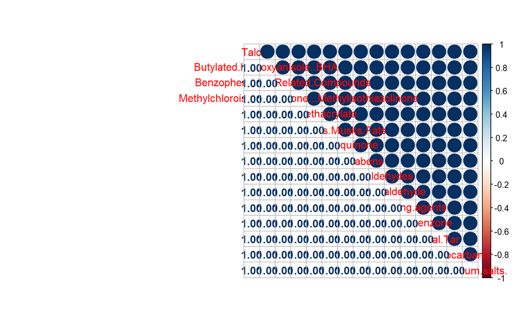

```r
corrplot_range(seph_in[, 36:50], 15)
```

Here we see the first 2 ingredients, limonene and linanool have a relatively high correlation at 0.69. Which is still lower the the general cutoff of 0.8.Though I want to keep it.

The last 26-50 ingredients are so ridiculously correlated with each other. we can just get rid of them

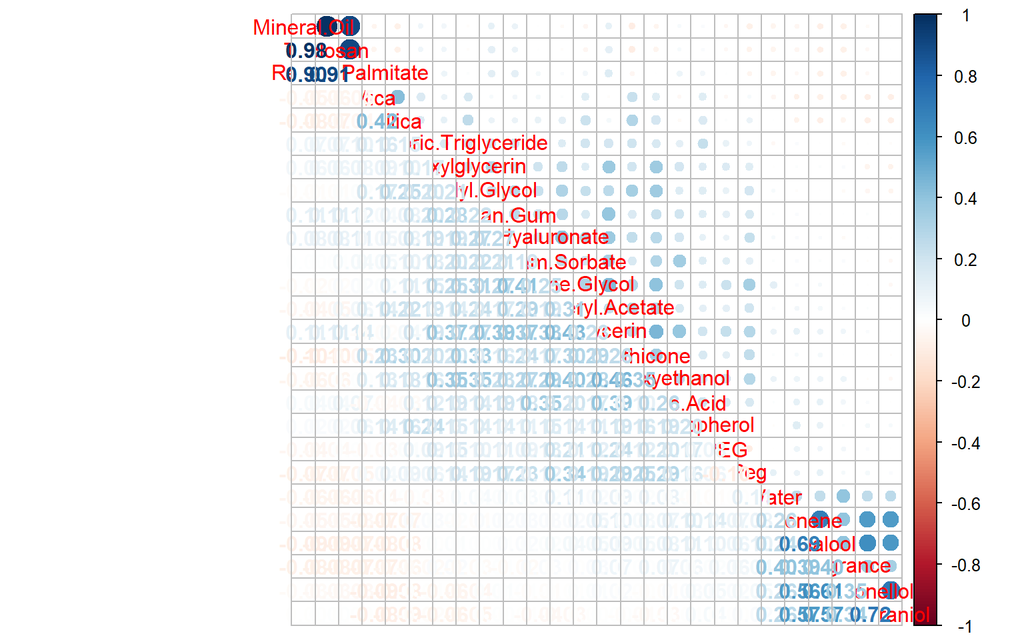

```r
seph_in_short <- seph_in[, 1:26]
corrplot_range(seph_in_short, 26)
```

```r
phi <- cor(seph_in_short, method = "pearson")
```

It’s a little hard to see here, but Triclosan and mineral Oil have correlations of over 0.9 with each other and another variable. So we can get rid of those.

## Filetered Corrplot

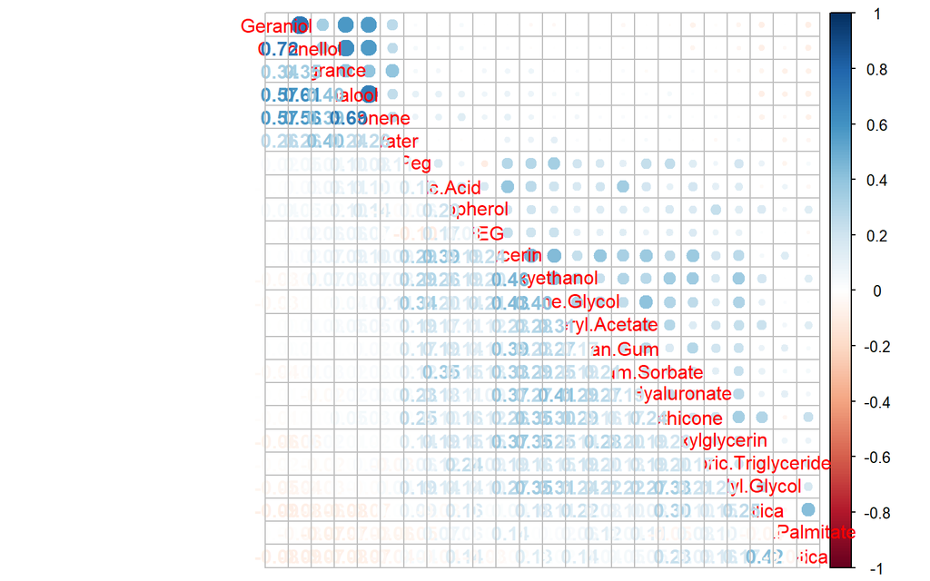

```r
excess <- c("Mineral.Oil", "Triclosan")
seph_in_short <-  seph_in_short[, -which(names(seph_in_short) %in% excess)]
corrplot_range(seph_in_short, 24)
```

```r
phi <-cor(seph_in_short, method = "pearson")
```

This looks much better and everything is below our threshold of 0.8! How wonderful! I’ll make a df of those ingredients with everything else.

```r
sepho <- seph[, 1:20] # Will remove list of ingredients, but keeps if ingredients are known
sephora <- cbind(sepho, seph_in_short)
head(sephora)
```

```
##   X      id          brand category rating number_of_reviews love price
## 1 0 2218774 Acqua Di Parma   Scents    4.0                 4 3002    66
## 2 1 2044816 Acqua Di Parma   Scents    4.5                76 2700    66
## 3 2 1417567 Acqua Di Parma   Scents    4.5                26 2600   180
## 4 3 1417617 Acqua Di Parma   Scents    4.5                23 2900   120
## 5 4 2218766 Acqua Di Parma   Scents    3.5                 2  943    72
## 6 5 1417609 Acqua Di Parma   Scents    4.5                79 2600   180
##   value_price MarketingFlags online_only exclusive limited_edition
## 1          75           True           1         0               0
## 2          66           True           1         0               0
## 3         180           True           1         0               0
## 4         120           True           1         0               0
## 5          80           True           1         0               0
## 6         180           True           1         0               0
##   limited_time_offer has_options has_instructions known_ingredients has_size
```

[output cut: 41 more lines]

# Average Price per Category

I was curious about average price of each category, as opposed to summing them up, so here that is. First let’s rerun Revathy’s code to have something to compare too

## Total Sum per Category

```r
price_sorted_category <- sephora %>%
  group_by(category) %>%
  summarise(price = sum(price)) %>%
  arrange(desc(price)) %>%
  slice_head(n = 10)
price_sorted_category
```

```
## # A tibble: 9 × 2
##   category   price
##   <chr>      <dbl>
## 1 Skincare 102961.
## 2 Scents    92967
## 3 Misc      72833.
## 4 Sets      40636.
## 5 Face      39414.
## 6 Haircare  34165.
## 7 Tools     32034.
## 8 Makeup    26771.
## 9 Body      19756.
```

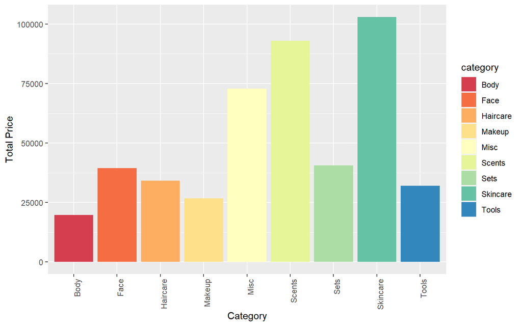

```r
ggplot(price_sorted_category, aes(x=category, y=price, fill=category)) +
geom_bar(stat="identity") +
scale_fill_brewer(palette="Spectral") +
theme(axis.text.x = element_text(angle = 90, hjust = 1)) +
labs(x="Category", y="Total Price")
```

## Mean per category

```r
price_sorted_category <- sephora %>%
  group_by(category) %>%
  summarise(price = mean(price)) %>%
  arrange(desc(price)) %>%
  slice_head(n = 10)
price_sorted_category
```

```
## # A tibble: 9 × 2
##   category price
##   <chr>    <dbl>
## 1 Scents   105.
## 2 Skincare  63.4
## 3 Sets      61.3
## 4 Tools     52.7
## 5 Body      42.5
## 6 Misc      36.6
## 7 Face      35.7
## 8 Haircare  33.0
## 9 Makeup    29.6
```

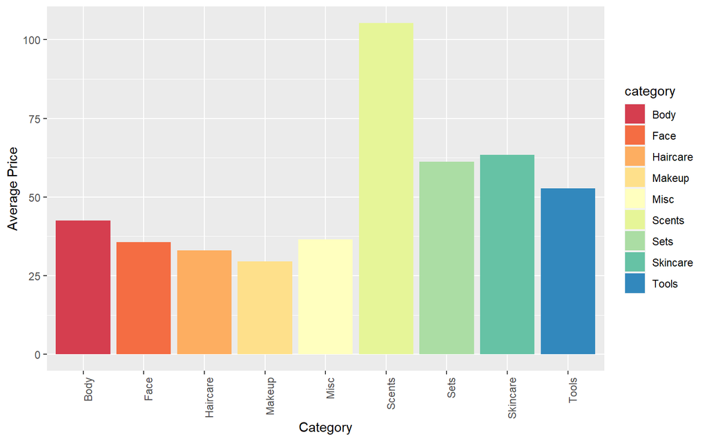

```r
ggplot(price_sorted_category, aes(x=category, y=price, fill=category)) +
geom_bar(stat="identity") +
scale_fill_brewer(palette="Spectral") +
theme(axis.text.x = element_text(angle = 90, hjust = 1)) +
labs(x="Category", y="Average Price")
```

Scents being expensive makes sense. There are tons of $100 perfumes. Interestingly enough, there is enough cheap skincare to bring down the mean, even though it had such a high total earlier in our EDA.

## Log price Boxplots

I also wanted to look at the log range of each one.

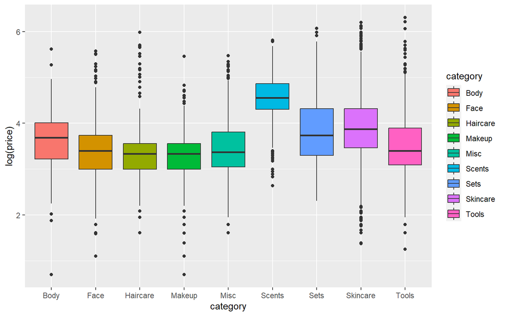

```r
ggplot(sephora, aes(x=category, y=log(price), fill= category)) +
  geom_boxplot()
```

# Oulier Removal

From here, we can see that we could benefit from removing outliers. (This categorization was also my doing, so there’s that. I’m impressed it even looks normalish anyway) What would constitute an outlier? Anything 3 or more z-scores away from the log price of the mean. Let’s clean that.

## Setting z-score

```r
sephora$log_price <- log(sephora$price)

sephora_z <- sephora %>%
  group_by(category) %>%
  mutate(zscore = scale(log_price)) %>%
  filter(abs(zscore) < 3) %>%
  ungroup()
```

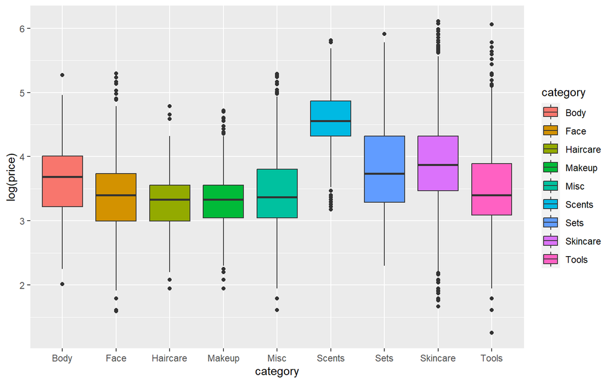

```r
ggplot(sephora_z, aes(x=category, y=log(price), fill= category)) +
  geom_boxplot()
```

We can see that made a minor difference in things like amakeup and haircare, (which essentially it should do)

Finally, let’s make a new csv just like that. I am removing the z-scores and keeping the log prices.

# Making a New CSV

```r
sephora <- sephora_z[, 1:45]
write.csv(sephora, "sephora_clean_v2.csv", row.names=FALSE)
```